# Hierarchical Clustering

## Theory

In the previous section, we examined how to recast the data into new coordinant spaces for visualization. Another ordination approach is to try to cluster our data. Hierarchical clustering are very helpful in understanding groupings in the data, particularly if there is a ‘nesting’ structure. While there are many ways to do it, they all generally proceed as follows:  
1. Define a numeric metric that measured the distances between all $K$ observations.  
2. Find the two groups that have the smallest distance and coalesce them together into a pair.  
3. Assume that the coalesced pair now constitutes a single entity, estimate the numeric metric among all $K-1$ groups in the data set.  
4. Go to #2 and repeat until you have coalesced all the groups together.

Here is an example of how this works. Consider the data below:

```r
x <- c(1, 2, 0, 3, 6)
y <- c(0, 3, 4, 2, 3)
coords <- cbind(x,y)
rownames(coords) <- LETTERS[1:5]
coords
```

```
  x y
A 1 0
B 2 3
C 0 4
D 3 2
E 6 3
```

If you assume a Euclidean Distance, you can see the pairwise distances as:

```r
dist( coords )
```

```
         A        B        C        D
B 3.162278
C 4.123106 2.236068
D 2.828427 1.414214 3.605551
E 5.830952 4.000000 6.082763 3.162278
```

Notice how the `rownames` on the `coords` object are perpetuated into the distance matrix. Here, $B$ and $D$ are the closest object. We can coalesce them by taking their mean coordinate. Here I manually take the 2nd and 4th entries and replace them with the mean values, I label them as $(BD)$

```r
x <- c(1, (2+3)/2, 0, 6)
y <- c(0, (3+2)/2, 4, 3)
coords <- cbind(x,y)
rownames(coords) <- c("A","(BD)","C","E")
coords
```

```
       x   y
A    1.0 0.0
(BD) 2.5 2.5
C    0.0 4.0
E    6.0 3.0
```

```r
dist(coords)
```

```
            A     (BD)        C
(BD) 2.915476
C    4.123106 2.915476
E    5.830952 3.535534 6.082763
```

Now, $A$ and $BD$ are the closest so I coalesce these into $(A(BD))$, take their mean coordinate and redo it again.

```r
x <- c( (1 +(2+3)/2)/2, 0, 6)
y <- c( (0 +(3+2)/2)/2, 4, 3)
coords <- cbind(x,y)
rownames(coords) <- c("(A(BD))","C","E")
coords
```

```
           x    y
(A(BD)) 1.75 1.25
C       0.00 4.00
E       6.00 3.00
```

```r
dist(coords)
```

```
   (A(BD))        C
C 3.259601
E 4.596194 6.082763
```

Then

```r
x <- c( ((1 +(2+3)/2)/2 + 0)/2, 6)
y <- c( ((0 +(3+2)/2)/2+ 4)/2, 3)
coords <- cbind(x,y)
rownames(coords) <- c("((A(BD))C)","E")
coords
```

```
               x     y
((A(BD))C) 0.875 2.625
E          6.000 3.000
```

```r
dist(coords)
```

```
  ((A(BD))C)
E   5.138701
```

Which is obviously resulting in $((A(BD))C)E$ as $E$ is the only one left. This means that if you group these, $BD$ go together, then $A$ attaches to that group then $C$ then $E$. Boom! You just did a hierarchical clustering!

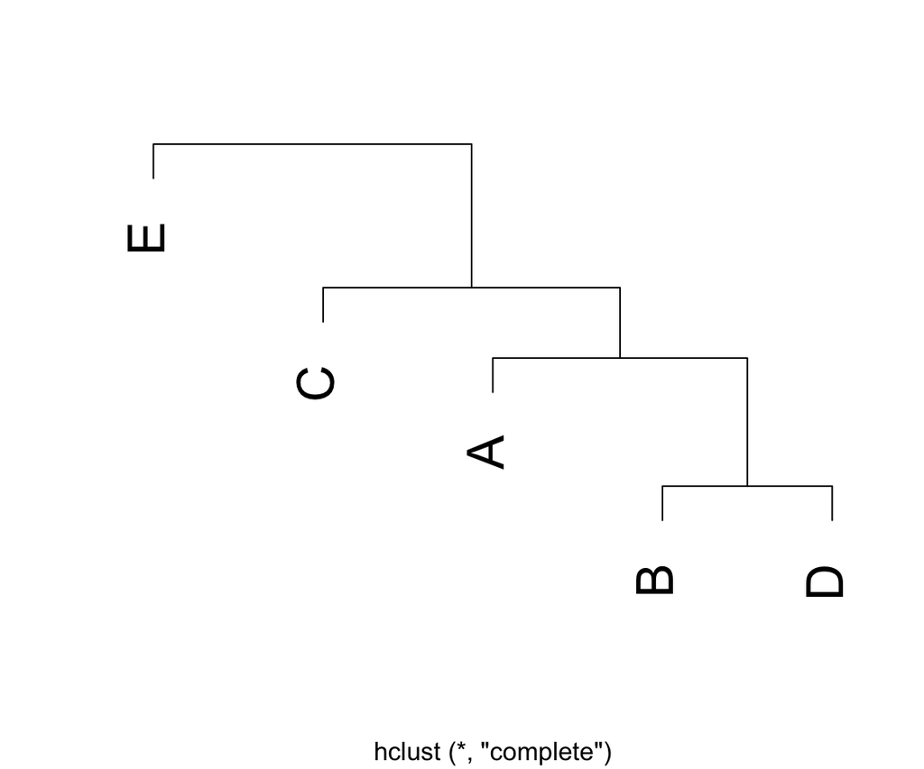

## A Real-Data Version

For a slightly more complicated version, we will be using the `beer style` data set. It can be loaded in from the Github site.

```r
url <- "https://raw.githubusercontent.com/dyerlab/ENVS-Lectures/master/data/Beer_Styles.csv"
read_csv( url ) %>%
  mutate( Yeast = as.factor( Yeast ) ) -> data
summary(data)
```

```
    Styles             Yeast       ABV_Min         ABV_Max
 Length:100         Ale   :69   Min.   :2.400   Min.   : 3.200
 Class :character   Either: 4   1st Qu.:4.200   1st Qu.: 5.475
 Mode  :character   Lager :27   Median :4.600   Median : 6.000
                                Mean   :4.947   Mean   : 6.768
                                3rd Qu.:5.500   3rd Qu.: 8.000
                                Max.   :9.000   Max.   :14.000
    IBU_Min         IBU_Max          SRM_Min         SRM_Max
 Min.   : 0.00   Min.   :  8.00   Min.   : 2.00   Min.   : 3.00
 1st Qu.:15.00   1st Qu.: 25.00   1st Qu.: 3.50   1st Qu.: 7.00
 Median :20.00   Median : 35.00   Median : 8.00   Median :17.00
 Mean   :21.97   Mean   : 38.98   Mean   : 9.82   Mean   :17.76
 3rd Qu.:25.00   3rd Qu.: 45.00   3rd Qu.:14.00   3rd Qu.:22.00
 Max.   :60.00   Max.   :120.00   Max.   :30.00   Max.   :40.00
     OG_Min          OG_Max          FG_Min          FG_Max
 Min.   :1.026   Min.   :1.032   Min.   :0.998   Min.   :1.006
 1st Qu.:1.040   1st Qu.:1.052   1st Qu.:1.008   1st Qu.:1.012
 Median :1.046   Median :1.060   Median :1.010   Median :1.015
 Mean   :1.049   Mean   :1.065   Mean   :1.009   Mean   :1.016
 3rd Qu.:1.056   3rd Qu.:1.075   3rd Qu.:1.010   3rd Qu.:1.018
 Max.   :1.080   Max.   :1.130   Max.   :1.020   Max.   :1.040
```

These data give ranges of values for each style but it is probably easier if we just take the midpoint of the range for what we are going to be doing here. So let’s fix that.

```r
data %>%
  mutate( ABV=( ABV_Max+ABV_Min)/2,
          IBU=( IBU_Max+IBU_Min)/2,
          SRM=( SRM_Max+SRM_Min)/2,
          OG=( OG_Max+OG_Min)/2,
          FG=( FG_Max+FG_Min)/2 )  %>%
  select( Styles, Yeast, ABV, IBU, SRM, OG, FG) -> beers
summary( beers)
```

```
    Styles             Yeast         ABV              IBU
 Length:100         Ale   :69   Min.   : 2.850   Min.   : 5.00
 Class :character   Either: 4   1st Qu.: 4.900   1st Qu.:21.38
 Mode  :character   Lager :27   Median : 5.300   Median :26.25
                                Mean   : 5.857   Mean   :30.48
                                3rd Qu.: 6.750   3rd Qu.:37.50
                                Max.   :11.500   Max.   :90.00
      SRM              OG              FG
 Min.   : 2.50   Min.   :1.030   Min.   :1.003
 1st Qu.: 5.00   1st Qu.:1.047   1st Qu.:1.010
 Median :12.75   Median :1.052   Median :1.012
 Mean   :13.79   Mean   :1.057   Mean   :1.013
 3rd Qu.:18.00   3rd Qu.:1.065   3rd Qu.:1.014
 Max.   :35.00   Max.   :1.100   Max.   :1.029
```

```r
m <- as.matrix( beers[,3:7])
rownames(m) <- beers$Styles
beer_dist <- dist( m )
h <- hclust( beer_dist )
h
```

```
Call:
hclust(d = beer_dist)

Cluster method   : complete
Distance         : euclidean
Number of objects: 100
```

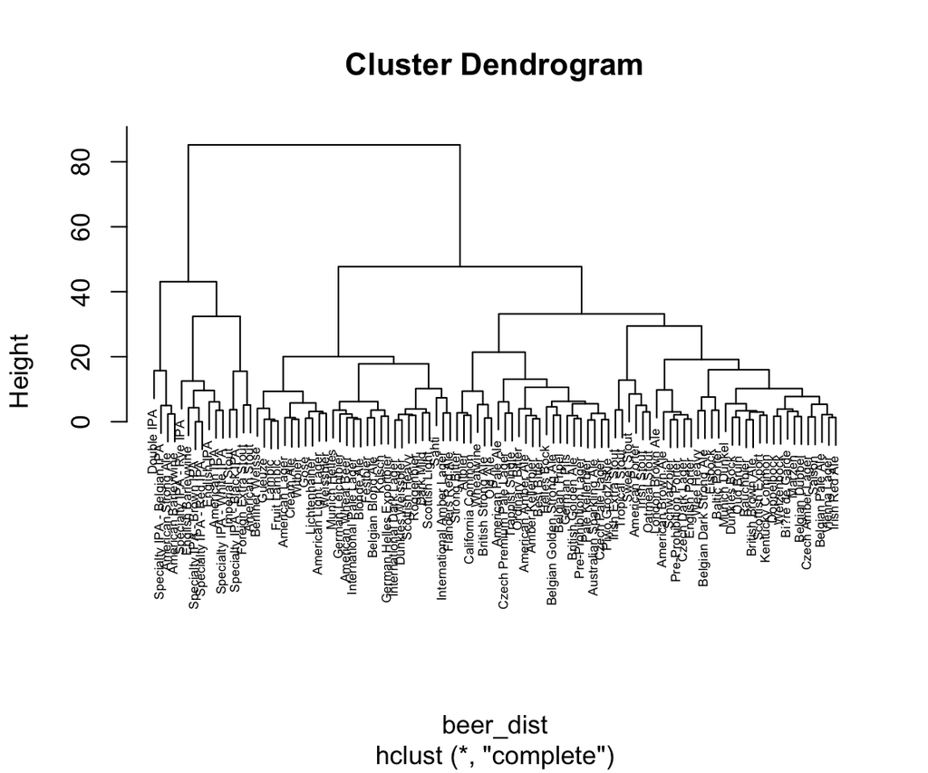

```r
plot(h, cex=0.5)
```

This is a bit confusing, so let’s play around with a little interactive interface to the data. This will not show up on the PDF version, you’ll have to look at the web version.

```r
library( networkD3 )
grp_colors <- c("red","green","blue")[as.numeric(as.factor(beers$Yeast))]
dendroNetwork( h, height=2400,
               zoom=TRUE,
               textColour=grp_colors)
```

There are other interactive ways to look at your data. A good set of examples can be found at https://christophergandrud.github.io/networkD3/